# Mini Proyecto 2

## 6.3 Matriz de confusión

La matriz muestra **con qué** se confunde cada objetivo, no solo cuánto falla. Se normaliza por fila para que cada una sume 1 y las clases minoritarias sean comparables con las grandes.

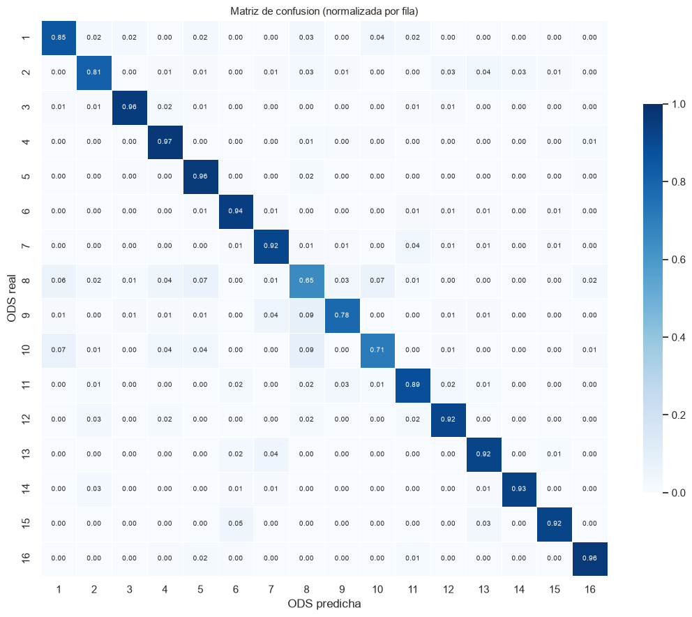

```
Pares de objetivos que mas se confunden:
```

|  | ods_real | nombre_real | ods_predicho | nombre_predicho | tasa | n_casos |
| --- | --- | --- | --- | --- | --- | --- |
| 0 | 9 | Industria, innovacion e infraestructura | 8 | Trabajo decente y crecimiento economico | 0.086957 | 6 |
| 1 | 10 | Reduccion de las desigualdades | 8 | Trabajo decente y crecimiento economico | 0.085714 | 6 |
| 2 | 10 | Reduccion de las desigualdades | 1 | Fin de la pobreza | 0.071429 | 5 |
| 3 | 8 | Trabajo decente y crecimiento economico | 5 | Igualdad de genero | 0.067416 | 6 |
| 4 | 8 | Trabajo decente y crecimiento economico | 10 | Reduccion de las desigualdades | 0.067416 | 6 |
| 5 | 8 | Trabajo decente y crecimiento economico | 1 | Fin de la pobreza | 0.056180 | 5 |
| 6 | 15 | Vida de ecosistemas terrestres | 6 | Agua limpia y saneamiento | 0.045455 | 3 |
| 7 | 8 | Trabajo decente y crecimiento economico | 4 | Educacion de calidad | 0.044944 | 4 |
| 8 | 9 | Industria, innovacion e infraestructura | 7 | Energia asequible y no contaminante | 0.043478 | 3 |
| 9 | 13 | Accion por el clima | 7 | Energia asequible y no contaminante | 0.043011 | 4 |

```python
# Matriz de confusion normalizada por fila.

def graficar_matriz_confusion(y_test, y_pred, normalizar=True, n_pares=10):
    """Dibuja la matriz de confusion y devuelve los pares mas confundidos.

    Retorna
    -------
    pd.DataFrame
        Los pares (real, predicho) con mayor tasa de confusion, excluida
        la diagonal.
    """
    etiquetas = sorted(pd.Series(y_test).unique())
    matriz = confusion_matrix(y_test, y_pred, labels=etiquetas)

    conteos = matriz.copy()

    if normalizar:
        sumas = matriz.sum(axis=1, keepdims=True)
        matriz = np.divide(matriz, sumas, out=np.zeros(matriz.shape, dtype=float),
                           where=sumas != 0)

    fig, ax = plt.subplots(figsize=(11, 9))
    sns.heatmap(
        matriz, annot=True, fmt=".2f" if normalizar else "d",
        cmap="Blues", cbar_kws={"shrink": 0.7},
        xticklabels=etiquetas, yticklabels=etiquetas,
        annot_kws={"size": 7}, linewidths=0.4, linecolor="white",
        vmin=0, vmax=1 if normalizar else None, ax=ax,
    )
    ax.set_xlabel("ODS predicha")
    ax.set_ylabel("ODS real")
    ax.set_title(
        "Matriz de confusion" + (" (normalizada por fila)" if normalizar else ""),
        fontsize=11,
    )
    plt.tight_layout()
    plt.show()

    # Pares mas confundidos, fuera de la diagonal
    fuera = matriz.copy()
    np.fill_diagonal(fuera, 0)

    i, j = np.unravel_index(np.argsort(fuera, axis=None)[::-1][:n_pares],
                            fuera.shape)

    pares = pd.DataFrame({
        "ods_real": [etiquetas[a] for a in i],
        "nombre_real": [NOMBRES_ODS.get(etiquetas[a], "?") for a in i],
        "ods_predicho": [etiquetas[b] for b in j],
        "nombre_predicho": [NOMBRES_ODS.get(etiquetas[b], "?") for b in j],
        "tasa": fuera[i, j],
        "n_casos": conteos[i, j],
    })

    return pares[pares["tasa"] > 0].reset_index(drop=True)

confusiones = graficar_matriz_confusion(y_test, y_pred)

print("Pares de objetivos que mas se confunden:")
display(confusiones)
```

## 6.4 Clasificación de textos concretos del conjunto de test

Se seleccionan a propósito **aciertos y errores**. Mostrar solo aciertos daría una imagen incompleta; los errores son los que revelan si el modelo se equivoca de forma razonable.

Para cada texto se muestra un fragmento, el ODS real, el predicho y —cuando el modelo lo permite— las **tres probabilidades más altas**.

```python
# Clasificacion de textos concretos del test, con aciertos y errores.

def puntuar_textos(modelo, textos):
    """Puntua textos con el modelo, den o no probabilidades sus clasificadores.

    No todos los algoritmos exponen predict_proba: LinearSVC, por ejemplo, solo
    tiene decision_function. Esta funcion unifica ambos casos para que el resto
    del notebook no tenga que distinguirlos.

    Retorna
    -------
    clases : ndarray
        Las etiquetas, en el orden de las columnas de 'puntuaciones'.
    puntuaciones : ndarray (n_textos, n_clases)
    es_probabilidad : bool
        True si son probabilidades reales; False si son puntuaciones de la
        funcion de decision, que no tienen escala fija ni suman 1.
    """
    if hasattr(modelo, "predict_proba"):
        return modelo.classes_, modelo.predict_proba(textos), True
    return modelo.classes_, modelo.decision_function(textos), False


def clasificar_ejemplos(modelo, X_test, y_test, y_pred, n_aciertos=3, n_errores=3,
                        semilla=SEMILLA, n_caracteres=400):
    """Muestra la prediccion del modelo sobre textos concretos del test.

    Elige aciertos y errores al azar con semilla fija, para que la seleccion
    sea reproducible y no este escogida a conveniencia.

    Retorna
    -------
    pd.DataFrame con los ejemplos y sus predicciones.
    """
    y_test = np.asarray(y_test)
    y_pred = np.asarray(y_pred)
    textos = pd.Series(X_test).reset_index(drop=True)

    aciertos = y_pred == y_test
    rng = np.random.default_rng(semilla)

    def sortear(mascara, n):
        posiciones = np.flatnonzero(mascara)
        if len(posiciones) <= n:
            return posiciones
        return rng.choice(posiciones, size=n, replace=False)

    elegidos = np.concatenate([
        sortear(aciertos, n_aciertos),
        sortear(~aciertos, n_errores)
    ])

    clases, puntuaciones, es_probabilidad = puntuar_textos(
        modelo, textos.iloc[elegidos]
    )

    filas = []

    for k, pos in enumerate(elegidos):
        orden = np.argsort(puntuaciones[k])[::-1][:3]
        if es_probabilidad:
            top3 = " | ".join(
                f"ODS {clases[i]}: {puntuaciones[k][i]:.0%}" for i in orden
            )
        else:
            top3 = " | ".join(
                f"ODS {clases[i]}: {puntuaciones[k][i]:.3f}" for i in orden
            )

        texto = textos.iloc[pos]
        fragmento = texto[:n_caracteres] + ("..." if len(texto) > n_caracteres else "")

        filas.append({
            "resultado": "acierto" if aciertos[pos] else "error",
            "ods_real": y_test[pos],
            "nombre_real": NOMBRES_ODS.get(y_test[pos], "?"),
            "ods_predicho": y_pred[pos],
            "nombre_predicho": NOMBRES_ODS.get(y_pred[pos], "?"),
            "top3": top3,
            "tipo_puntuacion": "probabilidad" if es_probabilidad else "puntuacion",
            "fragmento": fragmento,
        })

    return pd.DataFrame(filas)

ejemplos = clasificar_ejemplos(modelo_final, X_test, y_test, y_pred)

print(f"Ejemplos mostrados: {len(ejemplos)} "
      f"({(ejemplos['resultado'] == 'acierto').sum()} aciertos, "
      f"{(ejemplos['resultado'] == 'error').sum()} errores)")
if ejemplos["tipo_puntuacion"].iloc[0] != "probabilidad":
    print("El modelo no expone probabilidades: el Top 3 son puntuaciones de "
          "la funcion de decision, no porcentajes.")

# Se imprimen uno a uno: en una tabla los textos quedan ilegibles.
for _, fila in ejemplos.iterrows():
    estado = "ACIERTO" if fila["ods_real"] == fila["ods_predicho"] else "ERROR"
    print(f"\n{'=' * 78}\n[{estado}]")
    print(f"Texto     : {fila['fragmento']}")
    print(f"ODS real  : {fila['ods_real']} - {fila['nombre_real']}")
    print(f"Prediccion: {fila['ods_predicho']} - {fila['nombre_predicho']}")
    print(f"Top 3     : {fila['top3']}")
```

```
Ejemplos mostrados: 6 (3 aciertos, 3 errores)
El modelo no expone probabilidades: el Top 3 son puntuaciones de la funcion de decision, no porcentajes.

==============================================================================
[ACIERTO]
Texto     : "No especialista" incluye médico general, farmacéutico, enfermero, trabajador social u "alguien más". " Cualquier†tratamiento incluye tratamiento por especialista o no especialista. Este resultado se aplica a la proporción que buscó algún tratamiento, independientemente del proveedor esp…
ODS real  : 3 - Salud y bienestar
Prediccion: 3 - Salud y bienestar
Top 3     : ODS 3: 1.208 | ODS 15: -1.004 | ODS 10: -1.031

==============================================================================
[ACIERTO]
Texto     : La victoria del gobierno de Sri Lanka sobre los LTTE en 2009 aparentemente puso fin a más de 25 años de guerra civil. Sin embargo, las ramificaciones de la contrainsurgencia del gobierno van mucho más allá de la política interna de Sri Lanka. La campaña militar contra los LTTE plantea un…
ODS real  : 16 - Paz, justicia e instituciones solidas
Prediccion: 16 - Paz, justicia e instituciones solidas
Top 3     : ODS 16: 1.458 | ODS 13: -0.873 | ODS 1: -1.004

==============================================================================
[ACIERTO]
Texto     : El auge de la disciplina del derecho de gentes viene acompañado de una "moralización" de la noción de cosmopolitismo. Las obras de Hugo Grotius, Samuel Pufendorf y Emer de Vattel, catalogadas por Kant como los tristes consoladores del derecho internacional, muestran un positivismo progre…
ODS real  : 16 - Paz, justicia e instituciones solidas
Prediccion: 16 - Paz, justicia e instituciones solidas
Top 3     : ODS 16: 0.791 | ODS 14: -0.967 | ODS 10: -0.982

==============================================================================
[ERROR]
Texto     : En la década de 2000, España fue el principal beneficiario de este pico arancelario, representó el 71 por ciento de la producción de la UE en 2011 y desde 2001 ha sido el segundo mayor productor mundial de atún enlatado, solo por detrás de Tailandia (Globefish 2014). . Dadas las condicio…
ODS real  : 14 - Vida submarina
Prediccion: 2 - Hambre cero
Top 3     : ODS 2: -0.337 | ODS 7: -0.564 | ODS 9: -0.568

==============================================================================
[ERROR]
Texto     : Los datos del SCN sobre la renta de los hogares se dividen primero por el tamaño de la población. A continuación, se multiplican por la relación entre la renta media de los hogares de cada decil y la renta media de los hogares en el IDD, para obtener una estimación de la renta media de l…
ODS real  : 8 - Trabajo decente y crecimiento economico
Prediccion: 10 - Reduccion de las desigualdades
Top 3     : ODS 10: 0.031 | ODS 8: -0.604 | ODS 1: -0.655

==============================================================================
[ERROR]
Texto     : Por lo tanto, los modeladores de big data deben tener especial cuidado al construir vínculos entre las variables de sus modelos, comprender la importancia de la interpretación y asumir la responsabilidad de los resultados. Como escribe la científica de datos y matemática Cathy O'Neil, "l…
ODS real  : 9 - Industria, innovacion e infraestructura
Prediccion: 5 - Igualdad de genero
Top 3     : ODS 5: -0.604 | ODS 3: -0.701 | ODS 12: -0.702
```

### Análisis de errores

**Las métricas reales están en §6.1**: exactitud del 90,5 % y macro-F1 de 0,884 sobre los 1.932 textos de test. Conviene subrayarlo porque §6.4 muestra tres aciertos y tres errores, y esa proporción **está impuesta por la función** —se le pidieron tres de cada— no medida.

#### El hallazgo principal: el modelo sabe cuándo no sabe

Al comparar las puntuaciones de los seis ejemplos aparece una separación limpia:

|  | Puntuación ganadora | Margen sobre la segunda |
| --- | --- | --- |
| Los tres **aciertos** | +0,791 a +1,458 | +1,76 a +2,33 |
| Los tres **errores** | −0,604 a +0,031 | +0,10 a +0,64 |

Cuando acierta, la clase ganadora tiene puntuación claramente positiva y saca más de 1,7 puntos a la siguiente. Cuando falla, la ganadora ronda el cero o es negativa —es decir, **ninguna clase convence al modelo**— y las tres primeras se apiñan en un margen estrecho.

Es una observación con consecuencias prácticas: **la confianza del modelo es una señal aprovechable**. Un umbral por debajo del cual la salida fuera "sin clasificar" habría marcado los tres errores como dudosos sin descartar ninguno de los aciertos.

#### Errores comprensibles y errores de etiqueta discutible

**ODS 8 → ODS 10** (renta de los hogares por deciles, personas desempleadas). Es la confusión más razonable de las tres, y no es aislada: la tabla de §6.3 sitúa el par 8↔10 entre los más frecuentes, en ambas direcciones. El texto trata simultáneamente de empleo y de distribución del ingreso, así que pertenece de forma legítima a los dos objetivos. **El ODS 8 real aparece segundo en el ranking**, a solo 0,635 de la opción elegida. No es tanto un fallo del modelo como una **limitación de la etiqueta única**: el conjunto obliga a elegir uno cuando el texto abarca dos.

**ODS 14 → ODS 2** (atún enlatado, producción y cuota de mercado). El texto habla de pesca desde una óptica comercial, así que el vocabulario alimentario tira hacia "Hambre cero" mientras la etiqueta atiende al recurso marino. La puntuación ganadora es negativa (−0,337), coherente con un caso que no encaja bien en ninguna clase.

**ODS 9 → ODS 5** (modelos de big data, Cathy O'Neil). Es el error más interesante y merece detalle. No aparece entre los pares frecuentes de §6.3: es una confusión **atípica**, no un patrón. Y tiene dos causas identificables:

- **El texto es muy corto**: unas 50 palabras, frente a la mediana de 105 del corpus. Con tan pocos términos, el vector TF-IDF queda casi vacío y hay poquísima evidencia sobre la que decidir.
- **No contiene vocabulario del ODS 9.** No menciona industria, infraestructura ni innovación; trata de responsabilidad en el diseño de modelos algorítmicos. Cabe incluso cuestionar la etiqueta: un texto sobre ética de los datos podría corresponder al 9, al 10 o al 16 según qué aspecto se priorice.

#### Relación con el desempeño por clase

**La causa del error no es la escasez de datos sino el solapamiento temático**

# 7. Conclusiones

### Sobre la representación

**TF-IDF crudo superó a LSA en los tres algoritmos**, con una ventaja de unos 2 puntos de macro-F1: 0,872 frente a 0,852 en el SVM lineal, 0,871 frente a 0,849 en la regresión logística y 0,809 frente a 0,794 en Random Forest. La diferencia dobla la desviación entre pliegues (~0,009), de modo que no es ruido, y su repetición en los tres algoritmos indica una propiedad del problema y no una casualidad de un modelo concreto.

#### Por qué pierde LSA

La razón no es que la reducción destruya información útil, sino que **resuelve un problema que estos algoritmos no tenían**. LSA acerca documentos que hablan de lo mismo con palabras distintas, y eso beneficia a cualquier método basado en distancias. Pero un modelo lineal no mide distancias entre documentos: busca un hiperplano que separe clases, y **cuanto mayor es la dimensionalidad más fácil le resulta encontrarlo**. Comprimir de 13.592 columnas a 300 le retira capacidad discriminativa sin compensarlo con nada.

Los hiperparámetros elegidos lo confirman: los dos modelos lineales seleccionaron **300 componentes, el máximo de la rejilla**. Que el óptimo caiga en el extremo superior indica que el techo estaba limitando —con más componentes probablemente habrían mejorado, acercándose a TF-IDF sin llegar a superarlo—. Es una limitación del diseño de la búsqueda que conviene declarar.

#### Dónde sí aporta LSA

Que pierda en clasificación no lo invalida: **en este proyecto cumple una función distinta e insustituible**. Es lo que hace posible la interpretación de tópicos de §3.4, donde quince componentes se leen como conceptos —derecho internacional, educación formal, salud— y se contrastan con los ODS. TF-IDF no ofrece nada equivalente: sus 13.592 columnas son términos sueltos, no conceptos.

La conclusión no es "LSA no sirve" sino **"LSA sirve para otra cosa"**. Como reducción previa a un clasificador lineal resulta contraproducente en este problema; como herramienta de exploración y descubrimiento de estructura latente es justamente lo que permitió entender cómo se organiza el vocabulario del corpus frente a los objetivos.

### Sobre el algoritmo

**El SVM lineal fue el modelo seleccionado**, con un macro-F1 de 0,872 en validación cruzada. Pero su ventaja sobre la regresión logística es de **0,0008**, más de diez veces menor que la desviación entre pliegues: un empate técnico que el criterio de §5.6 resolvió por coste computacional, dejando constancia de ambas candidatas. Afirmar que el SVM es superior sería sobreinterpretar el resultado; lo correcto es decir que **los dos modelos lineales son equivalentes en este problema**.

Frente a ellos, **Random Forest queda unos 6 puntos por debajo** en ambas representaciones (0,809 y 0,794). Esa sí es una diferencia real, muy superior a la desviación, y responde a la pregunta que se planteó al elegir los algoritmos en §5.1: **la frontera entre objetivos es esencialmente lineal**.

Conviene precisar qué significa eso. No quiere decir que no existan patrones en los datos —el modelo alcanza un macro-F1 de 0,88, muy lejos del 0,0625 del azar—, sino que **no hay interacciones complejas entre términos que un modelo no lineal pueda aprovechar**. La evidencia que distingue un ODS de otro está en qué términos aparecen y con qué peso, no en combinaciones del tipo "si aparece *agua* pero no *energía*, entonces…". Una suma ponderada de todos los términos basta, y es precisamente lo que hace un modelo lineal.

El comportamiento frente al número de componentes lo refuerza. Los dos modelos lineales eligieron **300 componentes, el máximo de la rejilla**, señal de que el techo estaba limitando y habrían usado más. Random Forest eligió **100, el mínimo**. La asimetría es coherente con cómo funciona cada uno: un árbol clasifica mediante cortes sucesivos sobre variables individuales, así que la dimensionalidad alta lo perjudica, mientras que un modelo lineal combina todas las variables a la vez y se beneficia de ella.

#### El desbalance resultó menos relevante de lo previsto

La rejilla incluía `class_weight="balanced"` precisamente para comprobar si compensar el desbalance de 3,5× ayudaba. Esa opción pondera cada clase de forma inversamente proporcional a su frecuencia: un error sobre el ODS 12 (312 textos) penalizaría 3,5 veces más que sobre el ODS 16 (1.080).

**Los dos modelos lineales sobre TF-IDF eligieron `None`**, es decir, no ponderar. La validación cruzada determinó que compensar no mejoraba el macro-F1, y hay una razón: con un desbalance moderado y usando **macro-F1 como métrica** —que ya otorga el mismo peso a las 16 clases al evaluar—, ponderar también durante el entrenamiento resulta redundante.

### Sobre los tópicos latentes

De los cinco componentes que inspeccionamos, cuatro resultaron reconocibles y uno no. El primero agrupa palabras genéricas (`pued`, `pais`, `desarroll`, `polit`) que aparecen en casi cualquier texto del corpus, y no corresponde a ningún ODS. Su varianza explicada lo confirma: 0,0009, unas cinco veces menos que la del segundo componente. No es que capture poco tema — es que apunta en la dirección media de todos los documentos, y por eso casi no los separa entre sí. Es un artefacto conocido de aplicar SVD sobre TF-IDF, no un fallo del ajuste.

Los otros cuatro sí tienen lectura. Los componentes 4 y 5 son los más limpios: uno reúne `educ`, `escuel`, `docent`, `aprendizaj` y el otro `salud`, `atencion`, `medic`, `pacient`. Se leen casi sin esfuerzo como ODS 4 y ODS 3. El componente 2 se orienta hacia el ODS 16 (`derech human`, `tribunal`, `internacional`), aunque con menos nitidez. El componente 3 es el problemático: mezcla `mujer` y `niñ` con `trabaj`, `laboral`, `emple` e `ingres`, de modo que ODS 5 y ODS 8 comparten la misma dirección del espacio latente.

Esto es lo interesante del resultado: el LSA **no vio ni una sola etiqueta**, y aun así señaló por adelantado el punto exacto donde el clasificador supervisado iba a equivocarse. Dos métodos independientes llegando al mismo diagnóstico es mejor evidencia que cualquiera de los dos por separado, y apunta a que el problema no está en el modelo sino en los textos: hablar de empleo femenino es simultáneamente hablar de igualdad de género y de trabajo decente, y ninguna representación basada en qué palabras aparecen va a resolver eso.

La relación también funciona en sentido contrario. Los componentes 4 y 5, los de lectura más limpia, corresponden a los ODS 4 y 3, con F1 de 0,947 y 0,963 —tercero y segundo mejores del conjunto—. Un tema que se aísla bien sin supervisión es un tema que después se clasifica bien con ella.

# 8. Clasificación de textos nuevos

Las secciones anteriores evaluaron el modelo sobre el conjunto de test: textos que no participaron en el aprendizaje, pero que **proceden del mismo corpus**. Esta sección hace algo distinto y complementario: le da textos **escritos desde cero**, en el registro del caso de uso real.

## Por qué el registro importa

El modelo aprendió de textos del OSDG-CD —resúmenes de artículos e informes, traducidos automáticamente al español con DeepL—. Pero el escenario que plantea el proyecto es otro: el UNFPA recogiendo **propuestas ciudadanas** de ejercicios de participación territorial. Son textos más cortos, coloquiales y escritos directamente en español, sin pasar por un traductor automático.

Los ejemplos de esta sección están redactados en **ese** registro, deliberadamente, y no imitando al corpus de entrenamiento. Así la sección no es una demostración sino una **prueba de transferencia**: mide si el método sirve para aquello que motivó el proyecto, no solo si reproduce lo que ya vio.

Cualquiera de los dos resultados aporta:

## Sobre los porcentajes de confianza

Para hacerlos legibles se aplica **softmax**, que los reescala a valores positivos que suman 100 %.

```python
# Clasificacion de un texto libre cualquiera.

def a_porcentajes(puntuaciones):
    """Reescala puntuaciones a valores positivos que suman 1, via softmax.

    NO son probabilidades calibradas: un SVM maximiza el margen entre clases,
    no modela probabilidades. Sirven para comparar los candidatos entre si y
    para leer el resultado, no para afirmar "hay un 70 % de que sea el ODS 4".

    Parametros
    ----------
    puntuaciones : ndarray (n_textos, n_clases)

    Retorna
    -------
    ndarray de la misma forma, cada fila sumando 1.
    """
    # Restar el maximo de cada fila antes de exponenciar evita el
    # desbordamiento numerico con puntuaciones grandes. No altera el
    # resultado: softmax es invariante a sumar una constante.
    z = puntuaciones - puntuaciones.max(axis=1, keepdims=True)
    exponenciales = np.exp(z)
    return exponenciales / exponenciales.sum(axis=1, keepdims=True)


def clasificar_texto(modelo, texto, n_top=3):
    """Asigna un ODS a un texto libre y devuelve los n_top candidatos.

    Parametros
    ----------
    modelo : Pipeline
        El pipeline completo, que acepta texto crudo.
    texto : str
        Un unico texto. Se envuelve en lista porque el pipeline espera un
        iterable de documentos, no una cadena: pasarle la cadena suelta la
        recorreria caracter a caracter.
    n_top : int
        Cuantos candidatos devolver.

    Retorna
    -------
    dict con 'ods', 'nombre', 'confianza', 'candidatos' y 'calibrado'.
    """
    clases, puntuaciones, es_probabilidad = puntuar_textos(modelo, [texto])

    # Si el modelo ya da probabilidades se respetan; si no, se reescalan.
    valores = puntuaciones if es_probabilidad else a_porcentajes(puntuaciones)
    valores = valores[0]

    orden = np.argsort(valores)[::-1][:n_top]

    candidatos = [
        {
            "ods": int(clases[i]),
            "nombre": NOMBRES_ODS.get(int(clases[i]), "?"),
            "confianza": float(valores[i]),
        }
        for i in orden
    ]

    return {
        "texto": texto,
        "ods": candidatos[0]["ods"],
        "nombre": candidatos[0]["nombre"],
        "confianza": candidatos[0]["confianza"],
        "candidatos": candidatos,
        "calibrado": es_probabilidad,
    }


def mostrar_clasificacion(resultado, ancho_barra=40, n_caracteres=260):
    """Imprime el resultado con una barra de confianza por candidato."""
    texto = resultado["texto"]
    fragmento = texto[:n_caracteres] + ("..." if len(texto) > n_caracteres else "")

    print("=" * 78)
    print(f"TEXTO: {fragmento}\n")

    for k, c in enumerate(resultado["candidatos"]):
        barra = "#" * int(round(c["confianza"] * ancho_barra))
        marca = "->" if k == 0 else "  "
        print(f"  {marca} ODS {c['ods']:2d}  {c['confianza']:6.1%}  "
              f"{barra:<{ancho_barra}}  {c['nombre']}")

    if not resultado["calibrado"]:
        print("\n  (porcentajes reescalados con softmax; no son probabilidades)")
```

```python
# Textos de prueba, escritos en registro de participacion ciudadana.
#
# EDITA ESTA LISTA para clasificar tus propios textos.
# 'ods_esperado' es lo que asignaria una persona, para poder contrastar;
# None si no corresponde a ningun objetivo.

TEXTOS_LIBRES = [
    {
        "ods_esperado": 11,
        "texto": (
            "Propongo que se mejore el alumbrado publico del barrio y que se "
            "amplie la frecuencia de los buses en horario nocturno. Muchas "
            "personas salimos tarde del trabajo y las calles estan oscuras, "
            "lo que genera inseguridad. Tambien haria falta arreglar las "
            "aceras, porque estan rotas y las personas mayores se caen."
        ),
    },
    {
        "ods_esperado": 6,
        "texto": (
            "En nuestra vereda el agua llega turbia y con mal olor. Llevamos "
            "meses reclamando y nadie viene a revisar el acueducto. Las "
            "familias tenemos que hervir el agua para poder cocinar y los "
            "ninos se han enfermado del estomago varias veces este ano."
        ),
    },
    {
        # Ambiguo a proposito: toca formacion, empleo e igualdad de genero.
        "ods_esperado": 5,
        "texto": (
            "Pedimos que se abran cursos de formacion tecnica para mujeres "
            "cabeza de familia que estan sin empleo. Muchas no terminaron el "
            "bachillerato y no consiguen trabajo formal, y con capacitacion "
            "podrian acceder a mejores ingresos para sus hogares."
        ),
    },
    {
        # Una sola frase: la mediana del corpus es de 105 palabras (§1.5).
        "ods_esperado": 13,
        "texto": "Hay que sembrar mas arboles para reducir el calor en la ciudad.",
    },
    {
        # Ajeno a los ODS: el modelo esta obligado a elegir uno igualmente.
        "ods_esperado": None,
        "texto": (
            "Para preparar el sancocho se necesita gallina, yuca, platano y "
            "mazorca. Se pone a hervir todo junto durante una hora larga y al "
            "final se le echa cilantro picado. Queda mejor si se cocina en "
            "fogon de lena y se sirve con arroz blanco y aguacate."
        ),
    },
]

resultados_libres = []

for caso in TEXTOS_LIBRES:
    resultado = clasificar_texto(modelo_final, caso["texto"])
    resultado["ods_esperado"] = caso["ods_esperado"]
    resultados_libres.append(resultado)
    mostrar_clasificacion(resultado)

# Tabla resumen enfrentando lo esperado con lo predicho.
resumen_libres = pd.DataFrame([
    {
        "ods_esperado": r["ods_esperado"],
        "ods_predicho": r["ods"],
        "nombre_predicho": r["nombre"],
        "confianza": round(r["confianza"], 3),
        "coincide": (r["ods_esperado"] == r["ods"]) if r["ods_esperado"] else None,
        "texto": r["texto"][:60] + "...",
    }
    for r in resultados_libres
])

print()
display(resumen_libres)
```

```
==============================================================================
TEXTO: Propongo que se mejore el alumbrado publico del barrio y que se amplie la frecuencia de los buses en horario nocturno. Muchas personas salimos tarde del trabajo y las calles estan oscuras, lo que genera inseguridad. Tambien haria falta arreglar las aceras, por...

  -> ODS 11   12.1%  #####                                     Ciudades y comunidades sostenibles
     ODS  5    9.8%  ####                                      Igualdad de genero
     ODS  3    8.1%  ###                                       Salud y bienestar

  (porcentajes reescalados con softmax; no son probabilidades)
==============================================================================
TEXTO: En nuestra vereda el agua llega turbia y con mal olor. Llevamos meses reclamando y nadie viene a revisar el acueducto. Las familias tenemos que hervir el agua para poder cocinar y los ninos se han enfermado del estomago varias veces este ano.

  -> ODS  6   27.1%  ###########                               Agua limpia y saneamiento
     ODS  5    7.0%  ###                                       Igualdad de genero
     ODS 15    5.9%  ##                                        Vida de ecosistemas terrestres

  (porcentajes reescalados con softmax; no son probabilidades)
==============================================================================
TEXTO: Pedimos que se abran cursos de formacion tecnica para mujeres cabeza de familia que estan sin empleo. Muchas no terminaron el bachillerato y no consiguen trabajo formal, y con capacitacion podrian acceder a mejores ingresos para sus hogares.

  -> ODS  5   19.0%  ########                                  Igualdad de genero
     ODS 10   11.6%  #####                                     Reduccion de las desigualdades
     ODS  8    9.2%  ####                                      Trabajo decente y crecimiento economico

  (porcentajes reescalados con softmax; no son probabilidades)
==============================================================================
TEXTO: Hay que sembrar mas arboles para reducir el calor en la ciudad.

  -> ODS 11   19.7%  ########                                  Ciudades y comunidades sostenibles
     ODS 13    9.3%  ####                                      Accion por el clima
     ODS 15    9.1%  ####                                      Vida de ecosistemas terrestres

  (porcentajes reescalados con softmax; no son probabilidades)
==============================================================================
TEXTO: Para preparar el sancocho se necesita gallina, yuca, platano y mazorca. Se pone a hervir todo junto durante una hora larga y al final se le echa cilantro picado. Queda mejor si se cocina en fogon de lena y se sirve con arroz blanco y aguacate.

  -> ODS  2   10.8%  ####                                      Hambre cero
     ODS 11    8.4%  ###                                       Ciudades y comunidades sostenibles
     ODS 12    8.1%  ###                                       Produccion y consumo responsables

  (porcentajes reescalados con softmax; no son probabilidades)
```

|  | ods_esperado | ods_predicho | nombre_predicho | confianza | coincide | texto |
| --- | --- | --- | --- | --- | --- | --- |
| 0 | 11.0 | 11 | Ciudades y comunidades sostenibles | 0.121 | True | Propongo que se mejore el alumbrado publico de... |
| 1 | 6.0 | 6 | Agua limpia y saneamiento | 0.271 | True | En nuestra vereda el agua llega turbia y con m... |
| 2 | 5.0 | 5 | Igualdad de genero | 0.190 | True | Pedimos que se abran cursos de formacion tecni... |
| 3 | 13.0 | 11 | Ciudades y comunidades sostenibles | 0.197 | False | Hay que sembrar mas arboles para reducir el ca... |
| 4 | NaN | 2 | Hambre cero | 0.108 | None | Para preparar el sancocho se necesita gallina,... |

## Persistencia del modelo

Ejecutar el notebook entero para clasificar un texto no es práctico. El modelo se guarda con `joblib`, que serializa el pipeline completo —normalizador, vectorizador, reducción si la hay y clasificador— en un solo archivo.

Guardar no basta: a continuación **se carga de nuevo y se comprueba que predice exactamente lo mismo**. El pipeline contiene `NormalizadorTexto`, una clase definida en este propio notebook.

```python
# Guardado del modelo y comprobacion de que se recupera intacto.

import joblib

RUTA_MODELO = os.path.join("modelos", "clasificador_ods.joblib")
os.makedirs("modelos", exist_ok=True)

joblib.dump(modelo_final, RUTA_MODELO, compress=3)
tamano = os.path.getsize(RUTA_MODELO) / 1024**2
print(f"Modelo guardado en {RUTA_MODELO} ({tamano:.1f} MB)")

# Guardar sin comprobar la carga es la mitad del trabajo: el pipeline contiene
# NormalizadorTexto, una clase definida en este notebook, y conviene verificar
# que se reconstruye en lugar de suponerlo.
modelo_cargado = joblib.load(RUTA_MODELO)

textos_control = [caso["texto"] for caso in TEXTOS_LIBRES]
iguales = np.array_equal(
    modelo_final.predict(textos_control),
    modelo_cargado.predict(textos_control),
)

print(f"El modelo cargado predice lo mismo que el original: {iguales}")
assert iguales, "El modelo recuperado no coincide con el original"
```

```
Modelo guardado en modelos/clasificador_ods.joblib (1.7 MB)
El modelo cargado predice lo mismo que el original: True
```

### Lectura de los resultados

**El modelo transfiere.** De los cuatro textos con objetivo asignable acertó tres, y lo hizo sobre textos de entre 12 y 51 palabras, muy por debajo de la mediana de 105 del corpus de entrenamiento. Están además escritos en registro coloquial y directamente en español, sin pasar por el traductor automático del que provienen todos los textos con los que aprendió. Que el rendimiento aguante ese triple cambio —longitud, registro y origen— es el resultado más relevante de esta sección: el sesgo de traducción que se señala como limitación no impidió la transferencia.

La propuesta sobre el acueducto es el caso más nítido: **27,1 % para el ODS 6**, más de cuatro veces la base uniforme de 6,25 % y veinte puntos por encima del segundo candidato. Palabras como *agua*, *acueducto* y *hervir* son evidencia léxica inequívoca, y el modelo la aprovecha igual que si viniera de un informe.

**El único error es comprensible, y el acierto quedó segundo.** "Hay que sembrar más árboles para reducir el calor en la ciudad" se etiquetó como ODS 13 y el modelo respondió ODS 11 (19,7 %), con el 13 en segunda posición (9,3 %). El texto menciona literalmente *la ciudad*, y reducir el calor urbano pertenece de forma razonable tanto a la acción climática como a las ciudades sostenibles. No es un fallo de comprensión sino otra manifestación de la etiqueta única.

Ahora bien, **la confianza no se comportó como esperábamos**. Al plantear la sección anticipamos que una sola frase, con muy pocos términos con peso, produciría una confianza baja. Ocurrió lo contrario: ese 19,7 % es la segunda puntuación más alta de las cinco, por encima del 12,1 % con el que acertó la propuesta sobre alumbrado. El modelo se equivocó **con seguridad**, no por falta de evidencia. Conviene dejarlo escrito porque contradice la intuición y porque tiene consecuencias para lo que viene.

**El texto ajeno destapa la limitación estructural.** La receta de sancocho no trata de ningún ODS y aun así recibió uno: **Hambre cero, con 10,8 %**. La elección es la más sensata de las dieciséis posibles —es el objetivo con vocabulario alimentario— y su confianza es la más baja del grupo, pero el sistema **está obligado a elegir** y elige. No existe una clase "ninguno".

La conclusión para §7 se refuerza y se matiza a la vez: el método necesita una vía para decir "esto no es ningún ODS", pero **un umbral sobre la confianza del clasificador no la proporciona por sí solo**. Haría falta algo distinto —un detector de fuera de dominio entrenado aparte, o reformular el problema como multietiqueta con la opción de no asignar ninguna—. Con cinco textos no se puede fijar ese umbral con rigor; lo que sí queda demostrado es que el problema existe y que la solución fácil no lo resuelve.

# 9. Bono: aplicación web

El enunciado propone como bonificación llevar el clasificador a una aplicación donde cualquiera pueda escribir un texto y obtener el ODS que le corresponde, sin instalar nada ni ejecutar el notebook.

## La aplicación

**https://mini-proyecto-01-hne87bx9idzdmk8ee8ecuu.streamlit.app/**

## Github

***https://github.com/JuanCodeA/mini-proyecto-01***

Está desplegada en **Streamlit Community Cloud**. Se abre en el navegador, se pega un texto en español y devuelve el objetivo asignado junto a los otros dos candidatos, con los mismos porcentajes y la misma advertencia sobre su interpretación que se explican en §8.

La aplicación **no reentrena nada**: carga el `clasificador_ods.joblib` guardado en §8.4 y reutiliza la misma lógica de inferencia de §8. Se comprobó que devuelve exactamente los mismos resultados que este notebook sobre los cinco textos de prueba, incluidos los porcentajes.

| Archivo | Qué contiene |
| --- | --- |
| `app/streamlit_app.py` | La interfaz: caja de texto, botón y resultado |
| `app/modelo_ods.py` | La clase del pipeline, el cargador y la inferencia |
| `app/requirements.txt` | Las dependencias del despliegue |

# 10. Declaración de uso de inteligencia artificial generativa

Este proyecto se desarrolló con apoyo de un asistente de inteligencia artificial generativa (**Claude**, de Anthropic, a través de Claude Code). Se declara aquí su uso de forma explícita porque el alcance de esa ayuda **no es uniforme a lo largo del notebook**: va desde la revisión de código propio hasta una sección redactada por completo por la herramienta.

## En qué se usó

[output not shown]

## Lo que no se delegó

**La implementación del código de las secciones 1 a 7 es propia.** La herramienta entregó firmas de función y comentarios `TODO`; el cuerpo de cada función lo escribieron los autores, y la intervención posterior de la IA fue de revisión, no de autoría.

**Las decisiones de diseño son propias**: qué algoritmos comparar, por qué macro-F1 y no exactitud, dónde partir los datos, qué umbrales fijar y cómo interpretar los tópicos frente a los ODS.

**Todas las celdas fueron ejecutadas y sus resultados verificados por los autores.** Las cifras que aparecen en el texto se contrastaron contra las salidas reales del notebook, no se dieron por buenas porque las propusiera la herramienta. En varios puntos esa verificación obligó a corregir afirmaciones sugeridas por la IA que los datos no sostenían.

## Por qué la sección 8 se declara aparte

La **sección 8 no forma parte de lo que pide el enunciado**. Se añadió por iniciativa propia, por curiosidad: queríamos ver cómo se comporta el modelo ante textos escritos desde cero en registro de participación ciudadana, que es el caso de uso real que motiva el proyecto pero que el corpus de entrenamiento no representa.

Esa sección —el planteamiento, las funciones `a_porcentajes`, `clasificar_texto` y `mostrar_clasificacion`, los cinco textos de prueba, el guardado del modelo y el comentario de los resultados— **fue producida en su totalidad con la herramienta**. Los autores definieron el objetivo y validaron la salida, pero no escribieron el código.

Se deja constancia para que la evaluación del trabajo propio se centre en las secciones 1 a 7, y para que la sección 8 se lea como lo que es: un añadido exploratorio, fuera del alcance exigido.